# HW2

STA-360/602, Spring 2018

Frank

1/16/2019

#### 1. Lab component

#### (a) Task 3. Write a function that takes as its inputs that data you simulated (or any data of the same type) and a sequence of $\theta$ values of length 1000 and produces Likelihood values based on the Binomial Likelihood. Plot your sequence and its corresponding Likelihood function.

```r
# Generating simulated data
set.seed(123)
obs.data <- rbinom(n = 100, size = 1, prob = 0.01)
head(obs.data)
```

```
## [1] 0 0 0 0 0 0
```

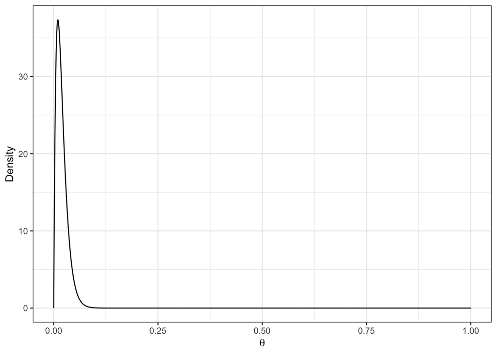

```r
# Create and plot likelihood function
n = length(obs.data)
x = sum(obs.data)
th = seq(0, 1, length = 1000)

like = dbeta(th, x+1, n-x+1)
ggplot()+geom_line(aes(x = th, y = like))+labs(x = expression(theta), y = "Density")+ theme_bw()
```

#### (b) Task 4. Write a function that takes as its inputs prior parameters a and b for the Beta-Bernoulli model and the observed data, and produces the posterior parameters you need for the model. Generate the posterior parameters for a non-informative prior i.e. $(a,b) = (1,1)$ and for an informative case $(a,b) = (3,1)$

```r
a1 = 1
b1 = 1
a2 = 3
b2 = 1

prior1 = dbeta(th, a1, b1)
post1 = dbeta(th, a1+x, b1+n-x)

prior2 = dbeta(th, a2, b2)
post2 = dbeta(th, a2+x, b2+n-x)
```

#### (c) Task 5. Create two plots, one for the informative and one for the non-informative case to show the posterior distribution and superimpose the prior distribu- tions on each along with the likelihood. What do you see? Remember to turn the y-axis ticks off since superimposing may make the scale non-sense.

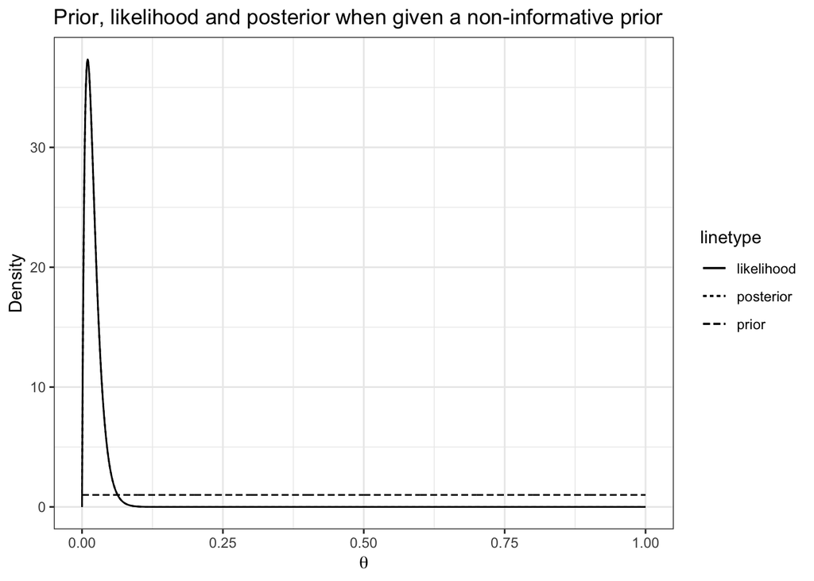

```r
# Plot for non-informative case
ggplot() +
  geom_line(aes(x = th, y = post1, linetype = 'posterior'))+
  geom_line(aes(x = th, y = prior1, linetype = 'prior'))+
  geom_line(aes(x = th, y = like, linetype = 'likelihood'))+
  labs(x = expression(theta), y = "Density", title = "Prior, likelihood and posterior when given a non-informative prior") + theme_bw()
```

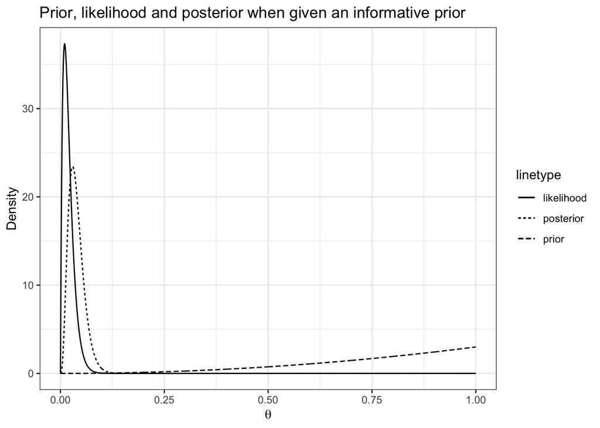

```r
# Plot for informative case
ggplot() +
  geom_line(aes(x = th, y = post2, linetype = 'posterior'))+
  geom_line(aes(x = th, y = prior2, linetype = 'prior'))+
  geom_line(aes(x = th, y = like, linetype = 'likelihood'))+
  labs(x = expression(theta), y = "Density", title = "Prior, likelihood and posterior when given an informative prior") + theme_bw()
```

#### 2. The *Exponential-Gamma Model* We write $X\sim Exp(\theta)$ to indicate that $X$ has the Exponential distribution, that is, its p.d.f. is

$$p(x|\theta) = Exp(x|\theta) = \theta\exp(-\theta x)1(x>0).$$
#### The Exponential distribution has some special properties that make it a good model for certain applications. It has been used to model the time between events (such as neuron spikes, website hits, neutrinos captured in a detector), extreme values such as maximum daily rainfall over a period of one year, or the amount of time until a product fails (lightbulbs are a standard example).

#### Suppose you have data $x_1,\dotsc,x_n$ which you are modeling as i.i.d. observations from an Exponential distribution, and suppose that your prior is $\theta\sim Gamma(a,b)$, that is,

$$p(\theta) = Gamma(\theta|a,b) = \frac{b^a}{\Gamma(a)}\theta^{a-1}\exp(-b\theta)1(\theta>0).$$

#### (a) Derive the formula for the posterior density, $p(\theta|x_{1:n})$. Give the form of the posterior in terms of one of the most common distributions (Bernoulli, Beta, Exponential, or Gamma).

$$\begin{align}p(\theta|x_{1:n}) & \propto p(x_{1:n}|\theta)p(\theta)\\
& \propto \prod_n[\theta\exp(-\theta x)]\frac{b^a}{\Gamma(a)}\theta^{a-1}\exp(-b\theta)\\
& \propto \theta^n\exp(-n\bar{x}\theta)\theta^{a-1}\exp(-b\theta)\\
& \propto \theta^{n+a-1}\exp[-(n\bar{x}+b)\theta]\\
& \propto Gamma(\theta|n+a,n\bar{x}+b)
\end{align}$$

#### (b) Why is the posterior distribution a *proper* density or probability distribution function?

Because the prior $p(\theta) = Gamma(\theta|a,b)$ is a conjugate prior for the given likelihood function. That means the posterior is in the same probability distribution family as the prior probability distribution $p(\theta)$ is.

#### (c) Now, suppose you are measuring the number of seconds between lightning strikes during a storm, your prior is $Gamma(0.1,1.0)$, and your data is

$$(x_1,\dotsc,x_8) = (20.9, 69.7, 3.6, 21.8, 21.4, 0.4, 6.7, 10.0).$$
Plot the prior and posterior p.d.f.s. (Be sure to make your plots on a scale that allows you to clearly see the important features.)

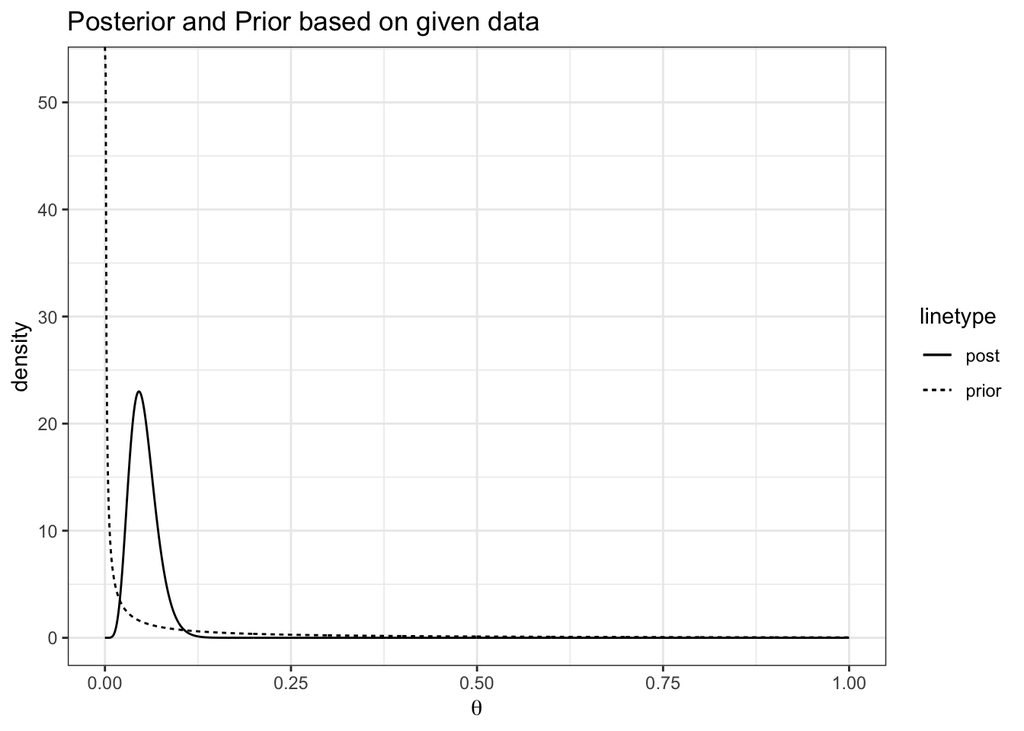

```r
X = c(20.9, 69.7, 3.6, 21.8, 21.4, 0.4, 6.7, 10.0)
th = seq(0,1,length = 1000)
x <- sum(X)
n <- length(X)
a = 0.1
b = 1.0

# Generate the prior and post function according to conclusions above
prior <- dgamma(th, a, b)
post <- dgamma(th, a + n, b + x)

# Plotting
ggplot()+geom_line(aes(x = th, y = prior, linetype = 'prior'))+
  geom_line(aes(x = th, y = post, linetype = 'post'))+
  labs(x = expression(theta), y = 'density', title = 'Posterior and Prior based on given data') + theme_bw()
```

#### (d) Give a specific example of an application where an Exponential model would be reasonable. Give an example where an Exponential model would NOT be appropriate, and explain why.

Reasonable: The time that some radioactive matter decays.

Unreasonable: The amount of flying bugs in different hours of day. Because most bugs are only active during night time, which is not constant throughout the day.

#### 3. *Priors, Posteriors, Predictive Distributions (Hoff, 3.9)*.

#### An unknown quantity $Y$ has a Galenshore($a, \theta$) distribution if its density is given by

$$p(y) = \frac{2}{\Gamma(a)} \; \theta^{2a} y^{2a - 1} e^{-\theta^2 y^2}$$
for $y>0, \theta >0, a>0.$ Assume for now that $a$ is known. For this density,
$$E[Y] = \frac{\Gamma(a +1/2)}{\theta \Gamma(a)}$$
and
$$E[Y^2] = \frac{a}{\theta^2}.$$

#### (a) Identify a class of conjugate prior densities for $\theta$. Plot a few members of this class of densities.

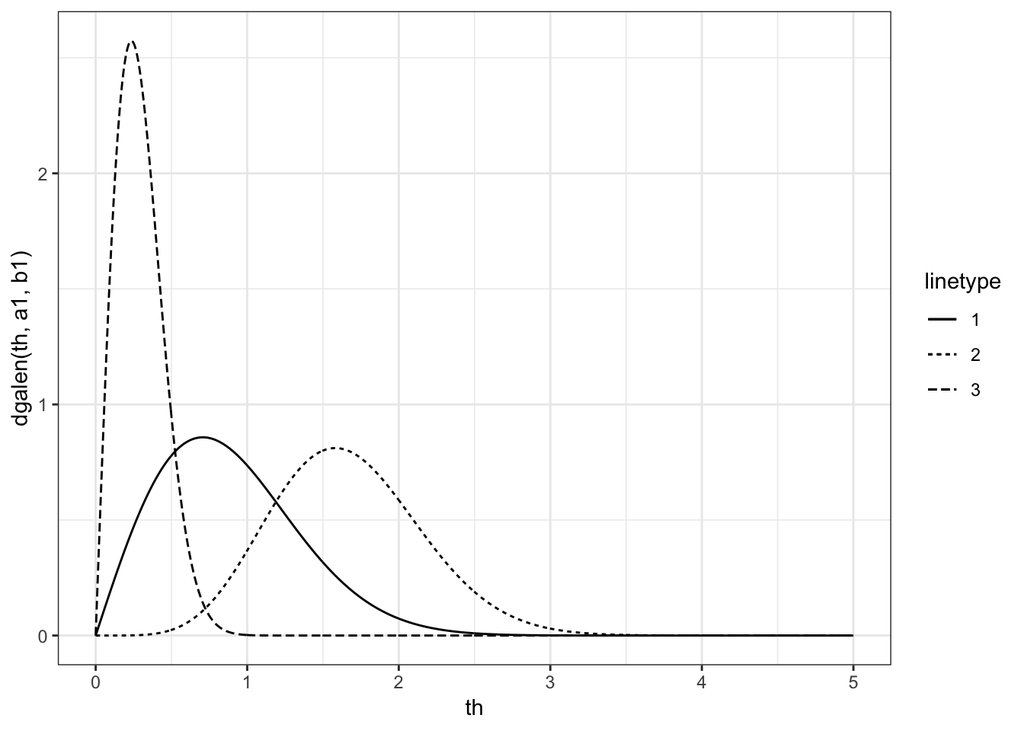

```r
# Define dgalen function
dgalen <- function(th,a,b){
  return(2/gamma(a)*b^(2*a)*th^(2*a-1)*exp(-b^2*th^2))
}
# Creating a set of (a, b) and theta for plotting
a1 = 1
b1 = 1
a2 = 3
b2 = 1
a3 = 1
b3 = 3
th = seq(0, 5, length = 1000)

# Plotting
ggplot()+geom_line(aes(x=th, y=dgalen(th,a1,b1),linetype='1'))+
  geom_line(aes(x=th, y=dgalen(th,a2,b2),linetype='2'))+
  geom_line(aes(x=th, y=dgalen(th,a3,b3),linetype='3'))+
  theme_bw()
```

#### (b) Let $Y_1, \ldots, Y_n \stackrel{iid}{\sim}$ Galenshore($a, \theta$). Find the posterior distribution of $\theta \mid y_{1:n}$ using a prior from your conjugate class.

Suppose the prior, $\theta$, is $\theta \sim$ Galenshore(k, b),

Given that Y has a Galenshore(a, $\theta$) distribution for y1,…,yn,

then the posterior is:

$$\begin{align}p(\theta|y_{1:n}) & \propto p(\theta)p(y_{1:n}|\theta)\\
& \propto \theta^{2k-1}\exp(-b^2\theta^2 )\prod_n [\theta^{2a}yi^{2a-1}\exp(-\theta^2yi^2)]\\
& \propto \theta^{2k-1}\exp(-b^2\theta^2 )\theta^{2an}\exp(-\theta^2\sum_n yi^2)\\
& \propto \theta^{2k+2an-1}\exp[-\theta^2(b^2+\sum_n yi^2)]\\
& \propto Galenshore(\alpha = k+an,\beta = \sqrt{b^2+\sum_n yi^2})
\end{align}$$

#### (c) Write down $$\frac{p(\theta_a \mid y_{1:n})}{p(\theta_b \mid y_{1:n})}$$ and simplify. Identify a sufficient statistic.

Given the result from (b), $p(\theta|y_{1:n}) \propto Galenshore(\alpha = k+an,\beta = \sqrt{b^2+\sum_n yi^2})$:

$$\frac{p(\theta_a \mid y_{1:n})}{p(\theta_b \mid y_{1:n})} = \frac{\theta_a^{2\alpha-1}exp(-\beta^2\theta_a^2)}{\theta_b^{2\alpha-1}exp(-\beta^2\theta_b^2)} = \bigg( \frac{\theta_a}{\theta_b}\bigg)^{2\alpha-1}exp[-\beta^2(\theta_a^2-\theta_b^2)]$$

Sufficient statistic: $\sum_n yi^2$

#### (d) Determine $E[\theta \mid y_{1:n}]$.

Since this is a conjugate family, and since given $Y \sim Galenshore(a,\theta)$,
$$E[Y] = \frac{\Gamma(a +1/2)}{\theta \Gamma(a)}$$

$$E[\theta \mid y_{1:n}] = \frac{\Gamma(\alpha +1/2)}{\beta \Gamma(\alpha)}\\
given: \alpha = k+an,\beta = \sqrt{b^2+\sum_n yi^2},\\
where: \theta \sim Galenshore(k, b)$$

#### (e) Determine the form of the posterior predictive density $p(y_{n+1} \mid y_{1:n})$

$$\begin{align} p(y_{n+1} \mid y_{1:n}) &= \int p(y_{n+1} |\theta) p(\theta|y_{1:n})d\theta\\
&= \int \frac{2}{\Gamma(a)} \; \theta^{2a} y_{n+1}^{2a - 1} e^{-\theta^2 y_{n+1}^2}\frac{2}{\Gamma(\alpha)} \; \beta^{2\alpha} \theta^{2\alpha - 1} e^{-\beta^2 \theta^2}d\theta\\
&= \frac{4}{\Gamma(a)\Gamma{(\alpha)}}y_{n+1}^{2a - 1}\beta^{2\alpha} \int \theta^{2(a+\alpha)-1} e^{-\theta^2(y_{n+1}^2 + \beta^2)}d\theta\\
&= \frac{4}{\Gamma(a)\Gamma{(\alpha)}}y_{n+1}^{2a - 1}\beta^{2\alpha} \int \frac{\Gamma(a+\alpha-\frac{1}{2})}{2}(y_{n+1}^2 + \beta^2)^{-(a+\alpha-\frac{1}{2})}\frac{2}{\Gamma(a+\alpha-\frac{1}{2})}(y_{n+1}^2 + \beta^2)^{a+\alpha-\frac{1}{2}}\theta^{2(a+\alpha-\frac{1}{2})-1} e^{-\theta^2(y_{n+1}^2 + \beta^2)}\theta d\theta\\
&= \frac{2\Gamma(a+\alpha-\frac{1}{2})}{\Gamma(a)\Gamma{(\alpha)}}y_{n+1}^{2a - 1}\beta^{2\alpha}(y_{n+1}^2 + \beta^2)^{-(a+\alpha-\frac{1}{2})}\int Galenshore(\theta|a+\alpha-\frac{1}{2}, \sqrt{y_{n+1}^2 + \beta^2})\theta d\theta\\
&\propto y_{n+1}^{2a - 1}(y_{n+1}^2 + \beta^2)^{-(a+\alpha-\frac{1}{2})}\frac{\Gamma(a+\alpha)}{\sqrt{y_{n+1}^2 + \beta^2}\Gamma(a+\alpha-\frac{1}{2})}\\
&\propto y_{n+1}^{2a - 1}(y_{n+1}^2 + \beta^2)^{-(a+\alpha)}
\end{align}$$

This is the simpliest form I can get, but I cannot recognize the family of the distribution.